# **Income Classification**

#### By Clint Greene

## Introduction

The income dataset was collected by the U.S. Census Bureau. It contains weighted census data extracted from the 1994 and 1995 Current Population Surveys. Each line of the dataset contains 40 demographic and employment related variables as well as an instance weight for the observation and a label for each observation, which indicates whether the particular population component had an income of greater than or less than $50k. The dataset contains a total of 199,523 instances.

### Objective

The goal is to predict whether a person makes over 50K a year or not given their demographic information. To achieve this, several machine learning algorithms are explored and the Light Gradient Boosted machine classifier gives the best performance.

## Data Loading

```python
import pandas as pd
import numpy as np
import seaborn as sns
from sklearn.metrics import jaccard_score, mean_squared_error, mean_absolute_error, precision_recall_curve
from sklearn.metrics import accuracy_score, f1_score, confusion_matrix, recall_score, precision_score, f1_score
import matplotlib.pyplot as plt
from mpl_toolkits.mplot3d import Axes3D
from sklearn.decomposition import PCA, KernelPCA
from sklearn.preprocessing import StandardScaler
import matplotlib.pyplot as plt
import seaborn as sns
import warnings
warnings.simplefilter(action='ignore', category=FutureWarning)
```

```python
# load data
data = pd.read_csv('census-income.data', sep=',', header=None)
column_names = pd.read_fwf('census-income.COLUMNS', header=None)

# set header
data.columns = column_names[0]

# map class labels to binary
data.loc[data['label'] == '- 50000.', 'label'] = 0
data.loc[data['label'] == '50000+.', 'label'] = 1
data['label'] = data['label'].astype(float)

data.head()
```

|  | age | class of worker | detailed industry recode | detailed occupation recode | education | wage per hour | enroll in edu inst last wk | marital stat | major industry code | major occupation code | ... | country of birth father | country of birth mother | country of birth self | citizenship | own business or self employed | fill inc questionnaire for veteran's admin | veterans benefits | weeks worked in year | year | label |
| --- | --- | --- | --- | --- | --- | --- | --- | --- | --- | --- | --- | --- | --- | --- | --- | --- | --- | --- | --- | --- | --- |
| 0 | 73 | Not in universe | 0 | 0 | High school graduate | 0 | Not in universe | Widowed | Not in universe or children | Not in universe | ... | United-States | United-States | United-States | Native- Born in the United States | 0 | Not in universe | 2 | 0 | 95 | 0.0 |
| 1 | 58 | Self-employed-not incorporated | 4 | 34 | Some college but no degree | 0 | Not in universe | Divorced | Construction | Precision production craft & repair | ... | United-States | United-States | United-States | Native- Born in the United States | 0 | Not in universe | 2 | 52 | 94 | 0.0 |
| 2 | 18 | Not in universe | 0 | 0 | 10th grade | 0 | High school | Never married | Not in universe or children | Not in universe | ... | Vietnam | Vietnam | Vietnam | Foreign born- Not a citizen of U S | 0 | Not in universe | 2 | 0 | 95 | 0.0 |
| 3 | 9 | Not in universe | 0 | 0 | Children | 0 | Not in universe | Never married | Not in universe or children | Not in universe | ... | United-States | United-States | United-States | Native- Born in the United States | 0 | Not in universe | 0 | 0 | 94 | 0.0 |
| 4 | 10 | Not in universe | 0 | 0 | Children | 0 | Not in universe | Never married | Not in universe or children | Not in universe | ... | United-States | United-States | United-States | Native- Born in the United States | 0 | Not in universe | 0 | 0 | 94 | 0.0 |

5 rows × 42 columns

```python
data.info()
```

```
<class 'pandas.core.frame.DataFrame'>
RangeIndex: 199523 entries, 0 to 199522
Data columns (total 42 columns):
 #   Column                                      Non-Null Count   Dtype
---  ------                                      --------------   -----
 0   age                                         199523 non-null  int64
 1   class of worker                             199523 non-null  object
 2   detailed industry recode                    199523 non-null  int64
 3   detailed occupation recode                  199523 non-null  int64
 4   education                                   199523 non-null  object
 5   wage per hour                               199523 non-null  int64
 6   enroll in edu inst last wk                  199523 non-null  object
 7   marital stat                                199523 non-null  object
 8   major industry code                         199523 non-null  object
 9   major occupation code                       199523 non-null  object
```

[output cut: 34 more lines]

### Description of demographic attributes

**1. Categorical Attributes**

- citizenship
- class of worker
- country of birth father
- country of birth mother
- country of birth self
- detailed household and family stat
- detailed household summary in household
- detailed industry recode
- detailed occupation recode
- enroll in edu inst last wk
- family members under 18
- fill inc questionnaire for veteran's admin
- full or part time employment stat
- hispanic origin
- live in this house 1 year ago
- major industry code
- major occupation code
- marital stat
- member of a labor union
- migration code-change in msa
- migration code-change in reg
- migration code-move within reg
- migration prev res in sunbelt
- num persons worked for employer
- own business or self employed
- race
- reason for unemployment
- region of previous residence
- sex
- state of previous residence
- tax filer stat
- veterans benefits
- year

**2. Continuous Attributes**

- age
- capital gains
- capital losses
- dividends from stocks
- wage per hour
- weeks worked in year

**3. Ordinal Attributes**

- education

Education with regards to predicting income level is in fact an ordinal attribute. Later we will map this to a continuous variable to reduce the feature space.

## Data Cleaning

Looking through the unique values per feature we can see that many features have missing values such as state of previous residence and major occupation code. Lets dive deeper and see just how many missing values exist in the samples. Here I will treat a sample as having a missing value if it contains '?', 'Do not know', 'Not in universe', or 'Not in universe or children'.

```python
vals = []
cols = []
for col in data.columns:
    a = data.loc[data[col] == "?", col].size
    b = data.loc[data[col] == "Not in universe", col].size
    c = data.loc[data[col] == "Do not know", col].size
    d = data.loc[data[col] == "Not in universe or children", col].size
    e = data.loc[data[col] == "Not in universe under 1 year old", col].size
    if a or b or c or d or e:
        vals.append([a,b,c,d,e])
        cols.append(col)
missing = pd.DataFrame(np.array(vals).T, columns = cols, index=['?', 'Not in universe', 'Do not know', 'Not in universe or children', 'Not in universe under 1 year old'])
missing.head()
```

|  | class of worker | enroll in edu inst last wk | major industry code | major occupation code | hispanic origin | member of a labor union | reason for unemployment | region of previous residence | state of previous residence | migration code-change in msa | migration code-change in reg | migration code-move within reg | live in this house 1 year ago | migration prev res in sunbelt | family members under 18 | country of birth father | country of birth mother | country of birth self | fill inc questionnaire for veteran's admin |
| --- | --- | --- | --- | --- | --- | --- | --- | --- | --- | --- | --- | --- | --- | --- | --- | --- | --- | --- | --- |
| ? | 0 | 0 | 0 | 0 | 0 | 0 | 0 | 0 | 708 | 99696 | 99696 | 99696 | 0 | 99696 | 0 | 6713 | 6119 | 3393 | 0 |
| Not in universe | 100245 | 186943 | 0 | 100684 | 0 | 180459 | 193453 | 183750 | 183750 | 1516 | 1516 | 1516 | 0 | 84054 | 144232 | 0 | 0 | 0 | 197539 |
| Do not know | 0 | 0 | 0 | 0 | 306 | 0 | 0 | 0 | 0 | 0 | 0 | 0 | 0 | 0 | 0 | 0 | 0 | 0 | 0 |
| Not in universe or children | 0 | 0 | 100684 | 0 | 0 | 0 | 0 | 0 | 0 | 0 | 0 | 0 | 0 | 0 | 0 | 0 | 0 | 0 | 0 |
| Not in universe under 1 year old | 0 | 0 | 0 | 0 | 0 | 0 | 0 | 0 | 0 | 0 | 0 | 0 | 101212 | 0 | 0 | 0 | 0 | 0 | 0 |

Many features contain over 90,000 missing values. Due to the sheer number of missing values it makes more sense to remove these features than attempt to impute them.

```python
#data.replace(['?', 'Not in universe', 'Do not know', 'Not in universe or children'], [-1, -1, -1, -1], inplace=True)
bad_features = [col for col in cols if missing[col].sum() > 10000]
print(bad_features)
```

[output not shown]

```python
data = data.drop(columns=bad_features)
print('Number of features removed: %s' %(len(bad_features)))
```

```
Number of features removed: 15
```

```python
vals = []
cols = []
for col in data.columns:
    a = data.loc[data[col] == "?", col].size
    b = data.loc[data[col] == "Not in universe", col].size
    c = data.loc[data[col] == "Do not know", col].size
    d = data.loc[data[col] == "Not in universe or children", col].size
    e = data.loc[data[col] == "Not in universe under 1 year old", col].size
    if a or b or c or d or e:
        vals.append([a,b,c,d,e])
        cols.append(col)
missing = pd.DataFrame(np.array(vals).T, columns = cols, index=['?', 'Not in universe', 'Do not know', 'Not in universe or children', 'Not in universe under 1 year old'])
missing.head()
```

|  | hispanic origin | country of birth father | country of birth mother | country of birth self |
| --- | --- | --- | --- | --- |
| ? | 0 | 6713 | 6119 | 3393 |
| Not in universe | 0 | 0 | 0 | 0 |
| Do not know | 306 | 0 | 0 | 0 |
| Not in universe or children | 0 | 0 | 0 | 0 |
| Not in universe under 1 year old | 0 | 0 | 0 | 0 |

There are still samples in hispanic origin, country of birth mother, country of birth father, and country of birth self which due to the small number relative to the total number of samples we can safely delete

```python
num_samples = data.shape[0]
data = data.loc[~((data['hispanic origin'] == 'Do not know') | (data['country of birth father']== '?')
                | (data['country of birth mother']== '?') | (data['country of birth self']== '?'))]
data.dropna(inplace=True)
print('Number of bad samples removed: %s' %(num_samples-data.shape[0]))
```

```
Number of bad samples removed: 9421
```

I decided to drop two additional categorical features: year and detailed household summary in household. Year was dropped because this attribute only signifies the year the census data that sample was collected and has no effect on income level. Detailed household summary in household was dropped because it is coarse and redudant version of detailed househould and family stat attribute. This reduces the feature space.

```python
data.drop(columns=['year', 'detailed household summary in household'], inplace=True)
```

```python
num_samples = data.shape[0]
data = data.drop_duplicates(keep = 'first')
print('Number of duplicate samples removed: %s' %(num_samples-data.shape[0]))
```

```
Number of duplicate samples removed: 4638
```

## Feature Plotting

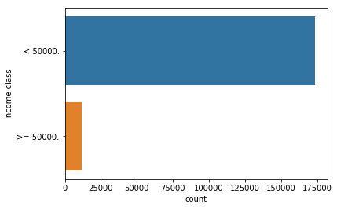

```python
new_df = pd.DataFrame(data['label'].values,columns=['income class'])
new_df.loc[new_df['income class'] == 0, 'income class'] = '< 50000.'
new_df.loc[new_df['income class'] == 1, 'income class'] = '>= 50000.'
sns.countplot(y='income class', data=new_df, order=new_df['income class'].value_counts().index)
```

Income levels less than 50k are 16 times more prevalent those above 50k. Dataset is very imbalanced.

```
The maximum age is 90
The minimum age is 0
```

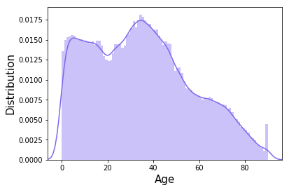

```python
sns.distplot(data['age'], bins = 90, color = 'mediumslateblue')
plt.ylabel('Distribution', fontsize = 15)
plt.xlabel('Age', fontsize = 15)
plt.margins(x = 0)

print ('The maximum age is', data['age'].max())
print ('The minimum age is', data['age'].min())
```

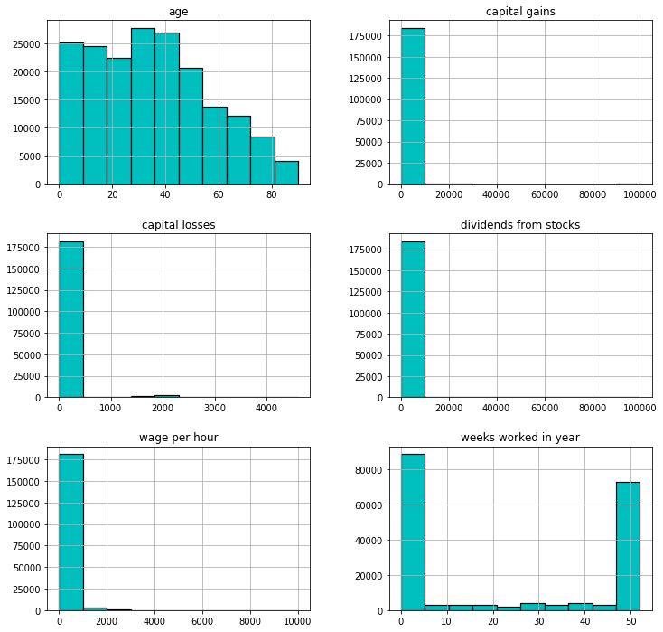

```python
data.hist(edgecolor = 'black', linewidth = 1.2, color = 'c')
fig = plt.gcf()
fig.set_size_inches(12,12)
plt.show()
```

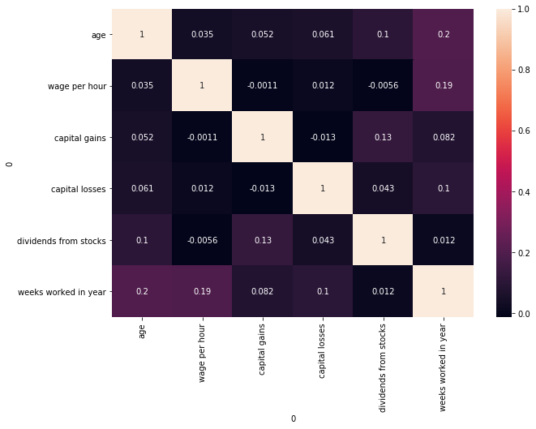

```python
plt.rcParams['figure.figsize'] = [10,7]
sns.heatmap(data.corr(), annot = True);
```

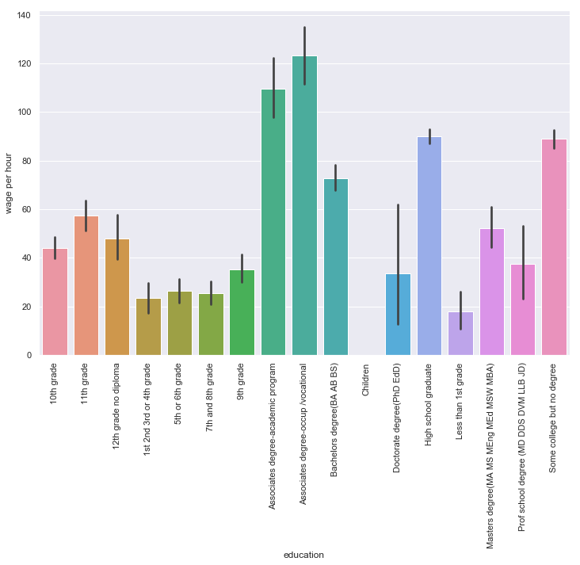

```python
sns.set(rc={'figure.figsize':(12,8)})
sns_grad = sns.barplot(x = data['education'], y = data['wage per hour'], data = data)
plt.setp(sns_grad.get_xticklabels(), rotation=90);
```

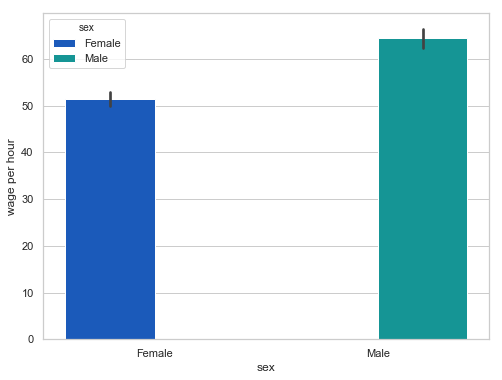

```python
sns.set(style = 'whitegrid', rc={'figure.figsize':(8,6)})
sns.barplot(x = data['sex'], y = data['wage per hour'], data = data,
            estimator = np.mean, hue = 'sex', palette = 'winter');
```

## Feature Engineering

```python
data['education'].value_counts()
```

```
High school graduate                      46102
Children                                  41434
Some college but no degree                26455
Bachelors degree(BA AB BS)                18639
7th and 8th grade                          7426
10th grade                                 7195
11th grade                                 6608
Masters degree(MA MS MEng MEd MSW MBA)     6105
9th grade                                  5952
Associates degree-occup /vocational        5110
Associates degree-academic program         4146
5th or 6th grade                           3116
12th grade no diploma                      1996
1st 2nd 3rd or 4th grade                   1707
Prof school degree (MD DDS DVM LLB JD)     1588
Doctorate degree(PhD EdD)                  1116
Less than 1st grade                         769
Name: education, dtype: int64
```

```python
edu_level = {'Children': 0,
'Less than 1st grade': 0.5,
'1st 2nd 3rd or 4th grade': 2.5,
'5th or 6th grade': 5.5,
'7th and 8th grade': 7.5,
'9th grade': 9,
'10th grade': 10,
'11th grade': 11,
'12th grade no diploma': 12,
'High school graduate': 13,
'Some college but no degree': 14,
'Associates degree-academic program': 15,
'Associates degree-occup /vocational': 15,
'Bachelors degree(BA AB BS)': 17,
'Masters degree(MA MS MEng MEd MSW MBA)': 19,
'Prof school degree (MD DDS DVM LLB JD)': 21,
'Doctorate degree(PhD EdD)': 22
            }
```

```python
data['edu_level'] = data['education'].astype(object)
for k,v in edu_level.items():
    data.loc[data['edu_level'] == k, 'edu_level'] = v
data['edu_level'] = np.float64(data['edu_level'])
data.drop(columns=['education'], inplace=True)
```

```python
def pipeline(data, num_features, ohe=True, add_features=True):
    from sklearn.preprocessing import OneHotEncoder
    num_data = data.copy(deep=True)[num_features]

    if add_features:
        num_data['age2'] = num_data['age']**2
        num_data['edu2'] = num_data['edu_level']**2
        num_data['capital net'] = num_data['capital gains'] - num_data['capital losses']

        num_features = num_features + ['age2', 'edu2', 'capital net']

    cat_features = [name for name in data.columns if name not in num_features]
    cat_data = data.copy(deep=True)[cat_features]
    if ohe:
        encoder = OneHotEncoder(drop='first', sparse=False)
        cat_data = encoder.fit_transform(cat_data)
        cat_names = encoder.get_feature_names(cat_features)
        cat_data = pd.DataFrame(data=cat_data,columns=cat_names)
    else: encoder = None

    piped_data = pd.concat([num_data.reset_index(drop=True), cat_data.reset_index(drop=True)], axis=1)
    return piped_data, num_features, encoder
```

```python
data_prepared, num_features, encoder = pipeline(data, num_features, add_features=False)
```

```python
for f in data_prepared.columns:
    data_prepared[f] = data_prepared[f].astype(float)
data_prepared.info()
```

```
<class 'pandas.core.frame.DataFrame'>
RangeIndex: 185464 entries, 0 to 185463
Columns: 309 entries, age to veterans benefits_2
dtypes: float64(309)
memory usage: 437.2 MB
```

## Model Selection

```python
from sklearn.model_selection import train_test_split
from copy import deepcopy

X_train, X_test, y_train, y_test = train_test_split(data_prepared, y, stratify=y, test_size=0.3, random_state=42)
X_cluster, y_cluster = deepcopy(X_test), deepcopy(y_test)
iw_cluster = X_cluster['instance weight']
X_cluster = X_cluster.drop(columns=['instance weight'])
X_test, X_val, y_test, y_val = train_test_split(X_test, y_test, stratify=y_test, test_size=0.5, random_state=42)
```

```python
#iw_cluster.to_pickle('cluster_sample_weights.pkl')
#X_cluster.to_pickle('cluster_data.pkl')
#y_cluster.to_pickle('cluster_labels.pkl')
iw_train, X_train = X_train['instance weight'], X_train.drop(columns=['instance weight'])
iw_test, X_test = X_test['instance weight'], X_test.drop(columns=['instance weight'])
iw_val, X_val = X_val['instance weight'], X_val.drop(columns=['instance weight'])
rng = 42
```

```python
from sklearn.model_selection import StratifiedShuffleSplit
from prunedcv import PrunedGridSearchCV
from sklearn.ensemble import RandomForestClassifier
from sklearn.linear_model import SGDClassifier

svmParams = {'penalty':['l1', 'l2'], 'alpha':np.logspace(-3, 3, 7)}
logParams = {'penalty':['l1', 'l2'], 'alpha':np.logspace(-3, 3, 7)}
forestParams = {'n_estimators':[100, 250, 500, 1000],'max_depth':[8, 16, 32, 64],
             'min_samples_split':[2, 5, 10, 25],'min_samples_leaf':[1, 2, 5, 10]}

svm = SGDClassifier(loss='hinge', class_weight='balanced', n_jobs=-1, early_stopping=True, n_iter_no_change=10,
                    validation_fraction=0.15, random_state=rng)
log = SGDClassifier(loss='log', class_weight='balanced', n_jobs=-1, early_stopping=True, n_iter_no_change=10,
                    validation_fraction=0.15, random_state=rng)
forest = RandomForestClassifier(class_weight='balanced_subsample', n_jobs=-1, random_state=rng)

params = [svmParams, logParams, forestParams]
models = [svm, log, forest]

sss_outer = StratifiedShuffleSplit(n_splits=5, test_size=0.4, random_state=rng)

cv = [[] for _ in range(len(models))]
for tr, ts in sss_outer.split(X_train,y_train):
    for i, (model, param) in enumerate(zip(models, params)):
        best_m = PrunedGridSearchCV(model, param, scoring='f1', cv=3, normalize=True)
        best_m.fit(X_train.iloc[tr], y_train.iloc[tr], sample_weight=iw_train.iloc[tr])
        sd = StandardScaler()
        sd.fit(X_train.iloc[tr])
        s = f1_score(y_train.iloc[ts], best_m.estimator.predict(sd.transform(X_train.iloc[ts])), sample_weight=iw_train.iloc[ts])
        cv[i].append((s,best_m.best_params))
```

```python
from lightgbm import LGBMClassifier
from sklearn.model_selection import RandomizedSearchCV
from scipy.stats import randint as sp_randint
from scipy.stats import uniform as sp_uniform

lgbParams = {'num_leaves': sp_randint(6, 50),
             'min_child_samples': sp_randint(100, 500),
             'min_child_weight': [1e-3, 1e-2, 1e-1, 1, 1e1, 1e2, 1e3],
             'subsample': sp_uniform(loc=0.2, scale=0.8),
             'colsample_bytree': sp_uniform(loc=0.4, scale=0.6),
             'reg_alpha': [0, 1e-1, 1, 2, 5, 7, 10, 50, 100],
             'learning_rate': [0.1, 0.05, 0.01, 0.005],
             'bagging_freq': [3, 4, 5, 6, 7],
             'min_data_in_leaf': [50, 100, 250, 500, 1000, 2000],
             'bagging_fraction': np.linspace(0.6, 0.95, 10),
             'reg_lambda': [0, 1e-1, 1, 5, 10, 20, 50, 100]
            }

fit_params={'early_stopping_rounds':15,
            'eval_metric' : f1,
            'eval_set' : [(X_val,y_val)],
            'eval_names': ['valid'],
            'sample_weight':iw_train,
            'verbose': 0}

lg = LGBMClassifier(n_estimators=1000, is_unbalance=True, metric='custom', importance_type='gain', objective='binary', verbose=1, random_state=42)
models = [lg]
params = [lgbParams]
sss_outer = StratifiedShuffleSplit(n_splits=5, test_size=0.4, random_state=rng)

new_cv = [[] for _ in range(len(models))]

for tr, ts in sss_outer.split(X_train,y_train):
    for i, (model, param) in enumerate(zip(models, params)):
        best_m = RandomizedSearchCV(model, param, n_iter=100, scoring='f1', cv=3, n_jobs=6)
        fit_params['sample_weight'] = iw_train.iloc[tr]
        best_m.fit(X_train.iloc[tr], y_train.iloc[tr], **fit_params)
        s = f1_score(y_train.iloc[ts], best_m.best_estimator_.predict(X_train.iloc[ts]), sample_weight=iw_train.iloc[ts])
        new_cv[i].append((s,best_m.best_params_))
#lg.fit(X_train, y_train, sample_weight=iw_train, early_stopping_rounds=15, eval_metric=f1, eval_set=[(X_val,y_val)])
```

[output not shown]

```python
cv = cv + new_cv
clfs = ['SVM', 'Logistic Regression', 'Random Forest', 'LightGBM']
avg_scores = []
curMax = [-float('inf')]
for ii in range(len(cv)):
    curRes = cv[ii]
    curAvg = []
    for jj in range(len(curRes)):
        curAvg.append(curRes[jj][0])
        if curRes[jj][0] > curMax[0]:
            curMax = (curRes[jj][0],curRes[jj][1],clfs[ii])
    avg_scores.append(np.mean(curAvg))
print('Top performing classifier over all sets was a %s with an average score: %s' %(clfs[np.argmax(avg_scores)], np.max(avg_scores)))
print('Max score %s found by %s with params %s' %(curMax[0], curMax[2], curMax[1]))
```

[output not shown]

```python
from lightgbm import LGBMClassifier
from sklearn.ensemble import RandomForestClassifier
from sklearn.linear_model import SGDClassifier

svm = SGDClassifier(loss='modified_huber', class_weight='balanced', n_jobs=-1, early_stopping=True, n_iter_no_change=30,
                    validation_fraction=0.20, random_state=rng, penalty='l2', alpha=1000)
log = SGDClassifier(loss='log', class_weight='balanced', n_jobs=-1, early_stopping=True, n_iter_no_change=30,
                    validation_fraction=0.20, random_state=rng, penalty='l1', alpha=1000)
lg = LGBMClassifier(n_jobs=-1, is_unbalanced=True, metric='custom', importance_type='gain',
                    objective='binary', verbose=1, bagging_fraction=0.67, bagging_freq=3, colsample_bytree=0.52,
                    learning_rate=0.05, min_child_samples=227, min_child_weight=1, min_data_in_leaf=100,
                    num_leaves=30, reg_alpha=1, reg_lambda=100, subsample=0.84)
forest = RandomForestClassifier(class_weight='balanced_subsample', n_jobs=-1, random_state=rng, n_estimators=100, max_depth=32, min_samples_split=2, min_samples_leaf=2)

forest.fit(X_train, y_train, sample_weight=iw_train)
log.fit(X_train, y_train, sample_weight=iw_train)
svm.fit(X_train, y_train, sample_weight=iw_train)
lg.fit(X_train, y_train, sample_weight=iw_train, early_stopping_rounds=15,
       eval_metric=f1, eval_set=[(X_val,y_val)], verbose=0)
```

```
LGBMClassifier(bagging_fraction=0.67, bagging_freq=3, boosting_type='gbdt',
               class_weight=None, colsample_bytree=0.52, importance_type='gain',
               is_unbalanced=True, learning_rate=0.05, max_depth=-1,
               metric='custom', min_child_samples=227, min_child_weight=1,
               min_data_in_leaf=100, min_split_gain=0.0, n_estimators=100,
               n_jobs=-1, num_leaves=30, objective='binary', random_state=None,
               reg_alpha=1, reg_lambda=100, silent=True, subsample=0.84,
               subsample_for_bin=200000, subsample_freq=0, verbose=1)
```

```python
y_pred_svm = svm.predict(X_test)
svm_score = f1_score(y_test,y_pred_svm,sample_weight=iw_test)
y_pred_log = log.predict(X_test)
log_score = f1_score(y_test,y_pred_log,sample_weight=iw_test)
y_pred_forest = forest.predict(X_test)
forest_score = f1_score(y_test,y_pred_forest,sample_weight=iw_test)
y_pred_lg = lg.predict(X_test)
lg_score = f1_score(y_test,y_pred_lg,sample_weight=iw_test)
scores = [svm_score, log_score, forest_score, lg_score]
clfs = ['SVM', 'Logistic Regression', 'Random Forest', 'LightGBM']
print('Final performance on test set')
for ii in range(len(clfs)):
    print('%s: %s' %(clfs[ii],scores[ii]))
```

```
Final performance on test set
SVM: 0.3673946969578005
Logistic Regression: 0.33879043768985007
Random Forest: 0.5098190101943634
LightGBM: 0.5399084857422197
```

```python
from sklearn.metrics import confusion_matrix
print(pd.DataFrame(confusion_matrix(y_test, y_pred_lg)))
```

```
       0    1
0  25805  269
1   1000  746
```

```python
print('Overfitting check')
y_pred_lg = lg.predict(X_train)
lg_train_score = f1_score(y_train,y_pred_lg,sample_weight=iw_train)
print('LGBM performance on training test: %s' %lg_train_score)
print('LGBM performance on testing test: %s' %lg_score)
```

```
Overfitting check
LGBM performance on training test: 0.5695525290379497
LGBM performance on testing test: 0.5399084857422197
```

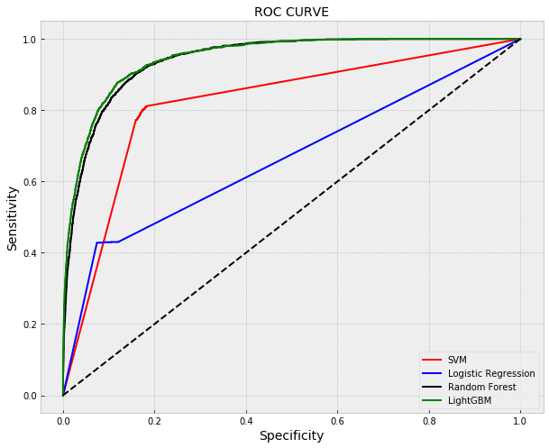

```python
from sklearn.metrics import roc_curve
from sklearn.metrics import f1_score
from sklearn.metrics import auc

models = [svm, log, forest, lg]

# Setting the parameters for the ROC Curve
plt.rcParams['figure.figsize'] = [10,8]
plt.style.use('bmh')

color = ['red', 'blue', 'black', 'green']
plt.title('ROC CURVE', fontsize = 14)
plt.xlabel('Specificity', fontsize = 14)
plt.ylabel('Sensitivity', fontsize = 14)

for i, model in enumerate(models) :
    prob = model.predict_proba(X_test)
    prob_positive = prob[:,1]
    fpr, tpr, threshold = roc_curve(y_test, prob_positive)
    plt.plot(fpr, tpr, color = color[i])
    plt.gca().legend(clfs, loc = 'lower right', frameon = True)

plt.plot([0,1],[0,1], linestyle = '--', color = 'black')
plt.show()
```

## Model Interpretation

```python
X_train, X_test, y_train, y_test = train_test_split(data.drop(columns=['label']), data['label'], stratify=y, test_size=0.3, random_state=42)
X_test, X_val, y_test, y_val = train_test_split(X_test, y_test, stratify=y_test, test_size=0.5, random_state=42)
iw_train, X_train = X_train['instance weight'], X_train.drop(columns=['instance weight'])
iw_test, X_test = X_test['instance weight'], X_test.drop(columns=['instance weight'])
iw_val, X_val = X_val['instance weight'], X_val.drop(columns=['instance weight'])
```

```python
lg = LGBMClassifier(n_jobs=-1, is_unbalanced=True, metric='custom', importance_type='gain',
                    objective='binary', verbose=1, bagging_fraction=0.67, bagging_freq=3, colsample_bytree=0.52,
                    learning_rate=0.05, min_child_samples=227, min_child_weight=1, min_data_in_leaf=100,
                    num_leaves=30, reg_alpha=1, reg_lambda=100, subsample=0.84)

lg.fit(X_train, y_train, early_stopping_rounds=15, eval_metric=f1, eval_set=[(X_val,y_val)], sample_weight=iw_train,
        verbose=0)
```

```
LGBMClassifier(bagging_fraction=0.67, bagging_freq=3, boosting_type='gbdt',
               class_weight=None, colsample_bytree=0.52, importance_type='gain',
               is_unbalanced=True, learning_rate=0.05, max_depth=-1,
               metric='custom', min_child_samples=227, min_child_weight=1,
               min_data_in_leaf=100, min_split_gain=0.0, n_estimators=100,
               n_jobs=-1, num_leaves=30, objective='binary', random_state=None,
               reg_alpha=1, reg_lambda=100, silent=True, subsample=0.84,
               subsample_for_bin=200000, subsample_freq=0, verbose=1)
```

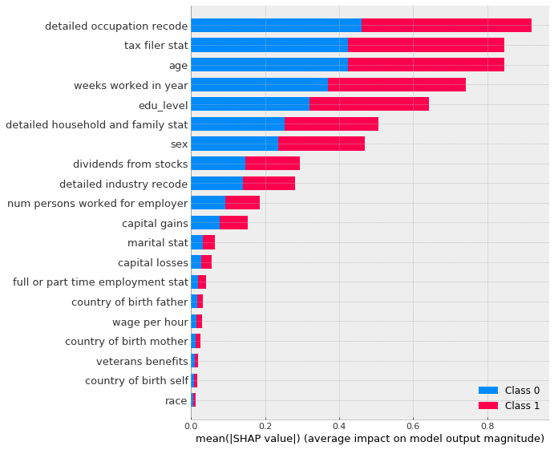

```python
import shap
shap.initjs()

explainer = shap.TreeExplainer(lg)
shap_values = explainer.shap_values(X_val,y_val)

shap.summary_plot(shap_values, X_val)
```

## Feature construction

```python
lg.fit(pipeline(X_train, num_features, ohe=False,add_features=True)[0], y_train, early_stopping_rounds=15, eval_metric=f1, eval_set=[(pipeline(X_val, num_features, ohe=False,add_features=True)[0],y_val)], sample_weight=iw_train,
        verbose=0)
```

```
LGBMClassifier(bagging_fraction=0.67, bagging_freq=3, boosting_type='gbdt',
               class_weight=None, colsample_bytree=0.52, importance_type='gain',
               is_unbalanced=True, learning_rate=0.05, max_depth=-1,
               metric='custom', min_child_samples=227, min_child_weight=1,
               min_data_in_leaf=100, min_split_gain=0.0, n_estimators=100,
               n_jobs=-1, num_leaves=30, objective='binary', random_state=None,
               reg_alpha=1, reg_lambda=100, silent=True, subsample=0.84,
               subsample_for_bin=200000, subsample_freq=0, verbose=1)
```

```
LightGBM binary classifier with TreeExplainer shap values output has changed to a list of ndarray
```

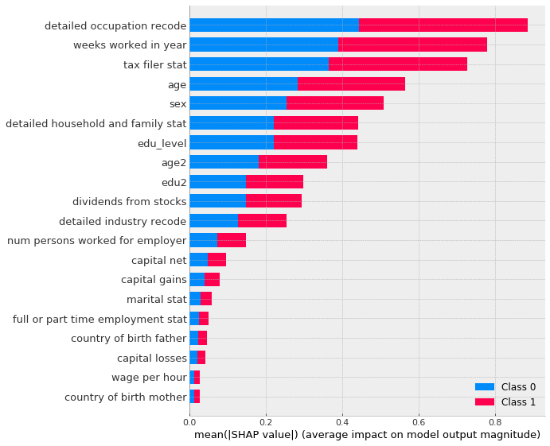

```python
explainer = shap.TreeExplainer(lg)
shap_values = explainer.shap_values(pipeline(X_val, num_features, ohe=False,add_features=True)[0],y_val)

shap.summary_plot(shap_values, pipeline(X_val, num_features, ohe=False,add_features=True)[0])
```

```python
y_pred_lg = lg.predict(X_test)
lg_old_score = f1_score(pd.get_dummies(y_test, drop_first=True),pd.get_dummies(y_pred_lg, drop_first=True),sample_weight=iw_test)
lg.fit(pipeline(X_train, num_features, ohe=False,add_features=True)[0], y_train, early_stopping_rounds=15, eval_metric=f1, eval_set=[(pipeline(X_val, num_features, ohe=False,add_features=True)[0],y_val)], sample_weight=iw_train,
        verbose=0)
y_pred_lg_new = lg.predict(pipeline(X_test, num_features, ohe=False,add_features=True)[0])
lg_new_score = f1_score(pd.get_dummies(y_test, drop_first=True),pd.get_dummies(y_pred_lg_new, drop_first=True),sample_weight=iw_test)
print('LGBM performance old performance: %s' %lg_old_score)
print('LGBM performance with new features: %s' %lg_new_score)
```

```
LGBM performance old performance: 0.5478010836285607
LGBM performance with new features: 0.552710738036397
```

# **Custom Segmentation**

```python
from sklearn.decomposition import PCA
from sklearn.preprocessing import StandardScaler
std = StandardScaler()
pca = PCA(n_components=3, svd_solver='randomized')
pca.fit(std.fit_transform(data_prepared))
X_p = pca.transform(std.fit_transform(data_prepared))
X_p.shape
```

```
(185464, 3)
```

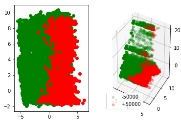

```python
#2D
plt.subplot(121)
plt.scatter(X_p[y==0][:,0], X_p[y==0][:,1],label='-50000', color='green')
plt.scatter(X_p[y==1][:,0], X_p[y==1][:,1],label='+50000', color='red')

# 3D
ax = plt.subplot(122,projection='3d')
#ax.view_init(-90, 120)
ax.scatter3D(X_p[y==0][:,0], X_p[y==0][:,1], X_p[y==0][:,2], label='-50000', color='green', alpha=0.2)
ax.scatter3D(X_p[y==1][:,0], X_p[y==1][:,1], X_p[y==1][:,2], label='+50000', color='red', alpha=0.3)
plt.legend()
```

```python
import umap
embedding = umap.UMAP(random_state=42,
                      n_neighbors=10,
                      min_dist=0.1,
                      n_components=2,
                      metric='manhattan',
                      init='random').fit(data_prepared)
```

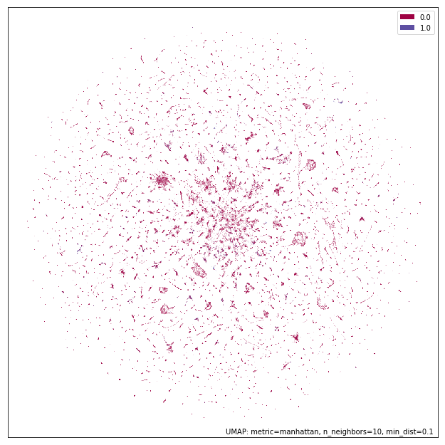

```python
import umap.plot
umap.plot.points(embedding, labels=y)
```

```python
import gower
from scipy.cluster.hierarchy import linkage, fcluster, dendrogram
```

```python
dm = np.load('downsampled_dm.npy')
dm = np.float64(dm)
```

```python
import hdbscan
percent_high = 0.0628 #np.sum(y!=0)/y.shape[0]
expect_num = percent_high * dm.shape[0]
num_samples = np.int(np.sqrt(expect_num))
expect_num = np.int(expect_num / 100)
print('min_cluster_size = %s, min_samples = %s' %(expect_num,num_samples))
```

```
min_cluster_size = 17, min_samples = 41
```

```python
clusterer = hdbscan.HDBSCAN(min_cluster_size=1000, min_samples=num_samples*2,
                            core_dist_n_jobs=8, metric='precomputed').fit(dm)
```

```python
print('Detected %s different groups of customers' %len(np.unique(clusterer.labels_)))
```

```
Detected 3 different groups of customers
```

```python
import umap
embedding = umap.UMAP(random_state=42,
                      n_neighbors=10,
                      min_dist=0.1,
                      n_components=2,
                      metric='manhattan',
                      init='random').fit(X_test)
```

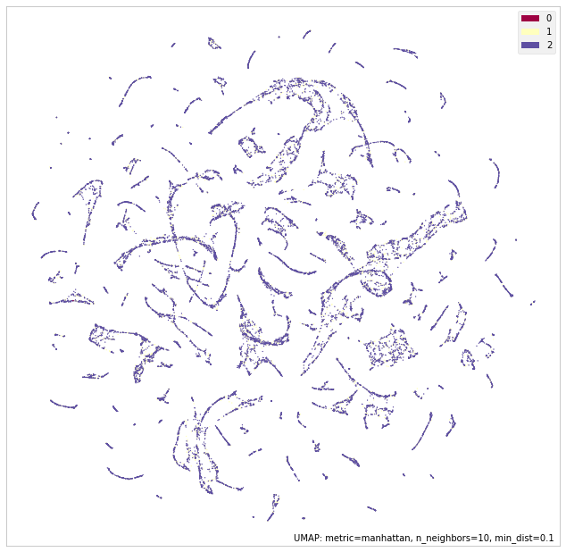

```python
import umap.plot
cl = np.array(clusterer.labels_) + 1
umap.plot.points(embedding, labels=cl)
```

```python
lb, cnt = np.unique(cl,return_counts=True)
print(lb, cnt)
print('Mapping label 0 to label 1')
cl[cl==0] = 1
```

[output not shown]

```python
lb, cnt = np.unique(cl,return_counts=True)
min_class = lb[np.argmin(cnt)]
maj_class = lb[np.argmax(cnt)]
y_clust = np.zeros((cl.shape[0],))
y_clust[cl == min_class] = 1
```

```python
f1_score(y_test.astype(int), y_clust, sample_weight=iw_test)
```

```
0.11811382694429313
```